# Unsupervised Learning Project_Prathinav

### PART A

```python
import pandas as pd
import seaborn as sns
import numpy as np
import matplotlib.pyplot as plt
%matplotlib inline
```

```python
df_car_names = pd.read_csv('Car name.csv')
df_car_attr = pd.read_json('Car-Attributes.json')
```

```python
df_car_merged = df_car_attr.merge(df_car_names, left_index=True, right_index=True)
df_car_merged.head()
```

|  | mpg | cyl | disp | hp | wt | acc | yr | origin | car_name |
| --- | --- | --- | --- | --- | --- | --- | --- | --- | --- |
| 0 | 18.0 | 8 | 307.0 | 130 | 3504 | 12.0 | 70 | 1 | chevrolet chevelle malibu |
| 1 | 15.0 | 8 | 350.0 | 165 | 3693 | 11.5 | 70 | 1 | buick skylark 320 |
| 2 | 18.0 | 8 | 318.0 | 150 | 3436 | 11.0 | 70 | 1 | plymouth satellite |
| 3 | 16.0 | 8 | 304.0 | 150 | 3433 | 12.0 | 70 | 1 | amc rebel sst |
| 4 | 17.0 | 8 | 302.0 | 140 | 3449 | 10.5 | 70 | 1 | ford torino |

```python
df_car_merged.to_csv('Cardata.csv', index=False)
```

```python
car_df = pd.read_csv('Cardata.csv')
car_df.head()
```

|  | mpg | cyl | disp | hp | wt | acc | yr | origin | car_name |
| --- | --- | --- | --- | --- | --- | --- | --- | --- | --- |
| 0 | 18.0 | 8 | 307.0 | 130 | 3504 | 12.0 | 70 | 1 | chevrolet chevelle malibu |
| 1 | 15.0 | 8 | 350.0 | 165 | 3693 | 11.5 | 70 | 1 | buick skylark 320 |
| 2 | 18.0 | 8 | 318.0 | 150 | 3436 | 11.0 | 70 | 1 | plymouth satellite |
| 3 | 16.0 | 8 | 304.0 | 150 | 3433 | 12.0 | 70 | 1 | amc rebel sst |
| 4 | 17.0 | 8 | 302.0 | 140 | 3449 | 10.5 | 70 | 1 | ford torino |

```python
car_df.info()
```

```
<class 'pandas.core.frame.DataFrame'>
RangeIndex: 398 entries, 0 to 397
Data columns (total 9 columns):
 #   Column    Non-Null Count  Dtype
---  ------    --------------  -----
 0   mpg       398 non-null    float64
 1   cyl       398 non-null    int64
 2   disp      398 non-null    float64
 3   hp        398 non-null    object
 4   wt        398 non-null    int64
 5   acc       398 non-null    float64
 6   yr        398 non-null    int64
 7   origin    398 non-null    int64
 8   car_name  398 non-null    object
dtypes: float64(3), int64(4), object(2)
memory usage: 28.1+ KB
```

```python
print(car_df.hp.unique())
```

```
['130' '165' '150' '140' '198' '220' '215' '225' '190' '170' '160' '95'
 '97' '85' '88' '46' '87' '90' '113' '200' '210' '193' '?' '100' '105'
 '175' '153' '180' '110' '72' '86' '70' '76' '65' '69' '60' '80' '54'
 '208' '155' '112' '92' '145' '137' '158' '167' '94' '107' '230' '49' '75'
 '91' '122' '67' '83' '78' '52' '61' '93' '148' '129' '96' '71' '98' '115'
 '53' '81' '79' '120' '152' '102' '108' '68' '58' '149' '89' '63' '48'
 '66' '139' '103' '125' '133' '138' '135' '142' '77' '62' '132' '84' '64'
 '74' '116' '82']
```

```python
car_df.hp = car_df.hp.replace('?', np.nan)

car_df.hp = car_df.hp.fillna(car_df.hp.median())   # fill it with median

# Convert it to float64
car_df.hp = car_df.hp.astype('float64')
print(car_df.hp.unique())
```

```
[130.  165.  150.  140.  198.  220.  215.  225.  190.  170.  160.   95.
  97.   85.   88.   46.   87.   90.  113.  200.  210.  193.   93.5 100.
 105.  175.  153.  180.  110.   72.   86.   70.   76.   65.   69.   60.
  80.   54.  208.  155.  112.   92.  145.  137.  158.  167.   94.  107.
 230.   49.   75.   91.  122.   67.   83.   78.   52.   61.   93.  148.
 129.   96.   71.   98.  115.   53.   81.   79.  120.  152.  102.  108.
  68.   58.  149.   89.   63.   48.   66.  139.  103.  125.  133.  138.
 135.  142.   77.   62.  132.   84.   64.   74.  116.   82. ]
```

```python
car_df.dtypes
```

```
mpg         float64
cyl           int64
disp        float64
hp          float64
wt            int64
acc         float64
yr            int64
origin        int64
car_name     object
dtype: object
```

```python
copy_df = car_df.copy()
copy_df.dtypes
```

```
mpg         float64
cyl           int64
disp        float64
hp          float64
wt            int64
acc         float64
yr            int64
origin        int64
car_name     object
dtype: object
```

### HP column has been imputed by removing the '?' value and replaced with the median. The column has been converted from object to float64

```python
car_df.describe()
```

|  | mpg | cyl | disp | hp | wt | acc | yr | origin |
| --- | --- | --- | --- | --- | --- | --- | --- | --- |
| count | 398.000000 | 398.000000 | 398.000000 | 398.000000 | 398.000000 | 398.000000 | 398.000000 | 398.000000 |
| mean | 23.514573 | 5.454774 | 193.425879 | 104.304020 | 2970.424623 | 15.568090 | 76.010050 | 1.572864 |
| std | 7.815984 | 1.701004 | 104.269838 | 38.222625 | 846.841774 | 2.757689 | 3.697627 | 0.802055 |
| min | 9.000000 | 3.000000 | 68.000000 | 46.000000 | 1613.000000 | 8.000000 | 70.000000 | 1.000000 |
| 25% | 17.500000 | 4.000000 | 104.250000 | 76.000000 | 2223.750000 | 13.825000 | 73.000000 | 1.000000 |
| 50% | 23.000000 | 4.000000 | 148.500000 | 93.500000 | 2803.500000 | 15.500000 | 76.000000 | 1.000000 |
| 75% | 29.000000 | 8.000000 | 262.000000 | 125.000000 | 3608.000000 | 17.175000 | 79.000000 | 2.000000 |
| max | 46.600000 | 8.000000 | 455.000000 | 230.000000 | 5140.000000 | 24.800000 | 82.000000 | 3.000000 |

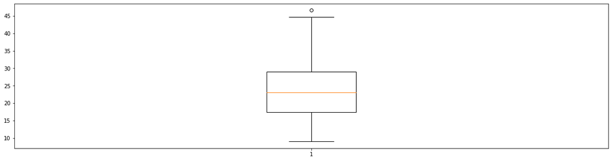

```python
plt.figure(figsize=(20,5))
plot_mpg = plt.boxplot(car_df['mpg'])
```

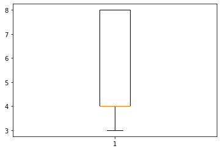

```python
plot_cyl = plt.boxplot(car_df['cyl'])
```

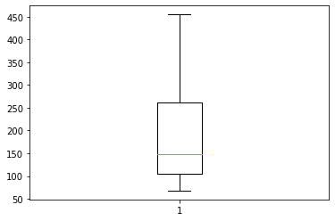

```python
plot_disp = plt.boxplot(car_df['disp'])
```

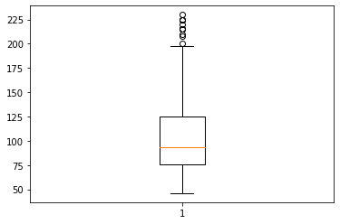

```python
plot_hp = plt.boxplot(car_df['hp'])
```

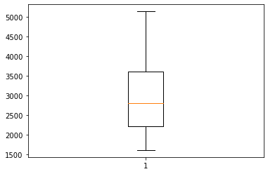

```python
plot_wt = plt.boxplot(car_df['wt'])
```

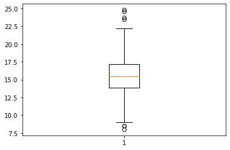

```python
plot_acc = plt.boxplot(car_df['acc'])
```

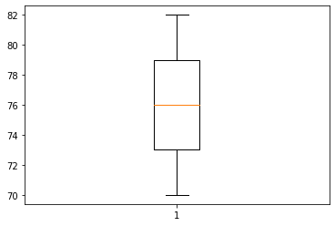

```python
plot_yr = plt.boxplot(car_df['yr'])
```

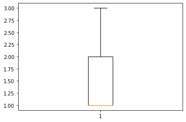

```python
plot_origin = plt.boxplot(car_df['origin'])
```

### Here we can see that 'mpg', 'acc', and 'hp' have outliers in the data. Remaining columns seem to be having consistent data.

```python
car_df.isna().sum()
```

```
mpg         0
cyl         0
disp        0
hp          0
wt          0
acc         0
yr          0
origin      0
car_name    0
dtype: int64
```

### Here we can see that the number of missing values or null values in the data are 0

```python
(1 - (car_df.isna()/len(car_df))).value_counts()
```

```
mpg  cyl  disp  hp   wt   acc  yr   origin  car_name
1.0  1.0  1.0   1.0  1.0  1.0  1.0  1.0     1.0         398
dtype: int64
```

### No missing values are present

```python
car_df.duplicated()
```

```
0      False
1      False
2      False
3      False
4      False
       ...
393    False
394    False
395    False
396    False
397    False
Length: 398, dtype: bool
```

```python
dupe=car_df[car_df.duplicated()]
```

```python
dupe
```

|  | mpg | cyl | disp | hp | wt | acc | yr | origin | car_name |
| --- | --- | --- | --- | --- | --- | --- | --- | --- | --- |

### no duplicate values

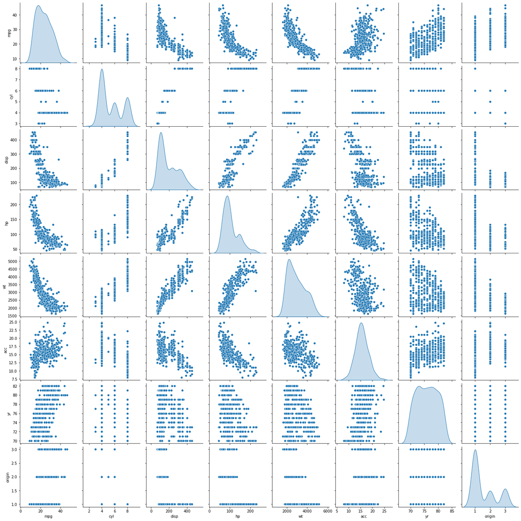

```python
sns.pairplot(car_df, diag_kind = 'kde')
plt.show()
```

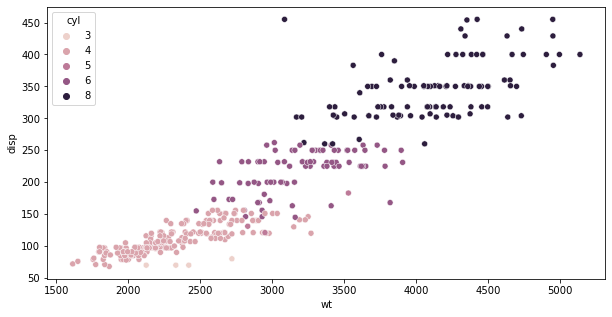

```python
plt.figure(figsize=(10,5))
sns.scatterplot(x='wt',y='disp',data=car_df,hue='cyl')
```

### As weight increases , the diplacement also increases, and higher weight and higher displacement is seen as the number of cylinders increase

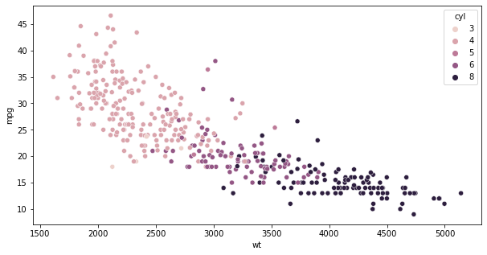

```python
plt.figure(figsize=(10,5))
sns.scatterplot(x='wt',y='mpg',data=car_df,hue='cyl')
```

### As weight increases , the mpg also decreases, and higher the number of cylinders, weight increases and mpg decreases

### Car name is not required while performing clustering, hence it will be removed

```python
car_df = car_df.drop(['car_name',], axis=1)
car_df.head()
```

|  | mpg | cyl | disp | hp | wt | acc | yr | origin |
| --- | --- | --- | --- | --- | --- | --- | --- | --- |
| 0 | 18.0 | 8 | 307.0 | 130.0 | 3504 | 12.0 | 70 | 1 |
| 1 | 15.0 | 8 | 350.0 | 165.0 | 3693 | 11.5 | 70 | 1 |
| 2 | 18.0 | 8 | 318.0 | 150.0 | 3436 | 11.0 | 70 | 1 |
| 3 | 16.0 | 8 | 304.0 | 150.0 | 3433 | 12.0 | 70 | 1 |
| 4 | 17.0 | 8 | 302.0 | 140.0 | 3449 | 10.5 | 70 | 1 |

### We will now be scaling the data

```python
from scipy.stats import zscore
car_df_scaled = car_df.apply(zscore)
car_df_scaled
```

|  | mpg | cyl | disp | hp | wt | acc | yr | origin |
| --- | --- | --- | --- | --- | --- | --- | --- | --- |
| 0 | -0.706439 | 1.498191 | 1.090604 | 0.673118 | 0.630870 | -1.295498 | -1.627426 | -0.715145 |
| 1 | -1.090751 | 1.498191 | 1.503514 | 1.589958 | 0.854333 | -1.477038 | -1.627426 | -0.715145 |
| 2 | -0.706439 | 1.498191 | 1.196232 | 1.197027 | 0.550470 | -1.658577 | -1.627426 | -0.715145 |
| 3 | -0.962647 | 1.498191 | 1.061796 | 1.197027 | 0.546923 | -1.295498 | -1.627426 | -0.715145 |
| 4 | -0.834543 | 1.498191 | 1.042591 | 0.935072 | 0.565841 | -1.840117 | -1.627426 | -0.715145 |
| ... | ... | ... | ... | ... | ... | ... | ... | ... |
| 393 | 0.446497 | -0.856321 | -0.513026 | -0.479482 | -0.213324 | 0.011586 | 1.621983 | -0.715145 |
| 394 | 2.624265 | -0.856321 | -0.925936 | -1.370127 | -0.993671 | 3.279296 | 1.621983 | 0.533222 |
| 395 | 1.087017 | -0.856321 | -0.561039 | -0.531873 | -0.798585 | -1.440730 | 1.621983 | -0.715145 |
| 396 | 0.574601 | -0.856321 | -0.705077 | -0.662850 | -0.408411 | 1.100822 | 1.621983 | -0.715145 |
| 397 | 0.958913 | -0.856321 | -0.714680 | -0.584264 | -0.296088 | 1.391285 | 1.621983 | -0.715145 |

398 rows × 8 columns

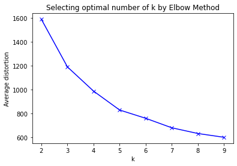

```python
from sklearn.cluster import KMeans
cars_clusters=range(2,10)
cars_wss=[]

for k in cars_clusters:
    cars_k_means_model = KMeans(n_clusters=k)
    cars_k_means_model.fit(car_df_scaled)
    cars_wss.append(cars_k_means_model.inertia_)

plt.plot(cars_clusters, cars_wss, 'bx-')
plt.xlabel('k')
plt.ylabel('Average distortion')
plt.title('Selecting optimal number of k by Elbow Method')
plt.show()
```

```python
### The optimal K value from the elbow graph is 5.
```

```python
k_means = KMeans(n_clusters = 5)
k_means.fit(car_df_scaled)
labels = k_means.labels_
```

```python
labels
```

```
array([3, 3, 3, 3, 3, 3, 3, 3, 3, 3, 3, 3, 3, 3, 2, 0, 0, 0, 2, 2, 2, 2,
       2, 2, 0, 3, 3, 3, 3, 2, 2, 2, 2, 0, 0, 0, 0, 0, 3, 3, 3, 3, 3, 3,
       3, 0, 2, 0, 0, 2, 2, 2, 2, 2, 2, 2, 2, 2, 2, 2, 2, 2, 3, 3, 3, 3,
       3, 3, 3, 3, 3, 2, 3, 3, 3, 3, 2, 2, 2, 2, 2, 2, 2, 2, 2, 3, 3, 3,
       3, 3, 3, 3, 3, 3, 3, 3, 3, 0, 0, 0, 0, 0, 2, 3, 3, 3, 3, 0, 2, 2,
       2, 2, 2, 0, 2, 3, 3, 2, 2, 2, 2, 3, 2, 2, 3, 0, 0, 0, 0, 1, 2, 1,
       2, 0, 0, 0, 3, 3, 3, 3, 3, 2, 2, 2, 1, 1, 2, 2, 2, 2, 2, 2, 0, 0,
       0, 0, 3, 3, 3, 3, 0, 0, 0, 0, 0, 0, 3, 2, 4, 0, 4, 2, 2, 2, 0, 2,
       0, 2, 2, 2, 2, 1, 2, 2, 4, 4, 2, 3, 3, 3, 3, 0, 0, 0, 0, 4, 4, 2,
       1, 0, 0, 0, 0, 2, 1, 1, 4, 2, 3, 2, 2, 0, 3, 3, 3, 3, 1, 4, 1, 4,
       1, 3, 0, 3, 3, 0, 0, 0, 0, 3, 3, 3, 3, 2, 4, 1, 4, 4, 4, 1, 2, 2,
       2, 2, 1, 4, 1, 1, 1, 0, 3, 3, 0, 0, 0, 4, 0, 0, 0, 0, 0, 0, 3, 0,
       3, 3, 4, 1, 1, 4, 2, 4, 4, 1, 2, 0, 2, 0, 1, 1, 0, 0, 4, 0, 0, 0,
       3, 3, 0, 3, 3, 0, 3, 1, 1, 4, 4, 4, 0, 4, 0, 4, 4, 1, 1, 4, 4, 4,
       4, 1, 1, 4, 1, 4, 4, 4, 0, 1, 1, 1, 1, 1, 1, 4, 1, 1, 1, 1, 4, 1,
       1, 1, 1, 1, 1, 1, 4, 1, 4, 4, 4, 4, 4, 1, 4, 1, 1, 1, 1, 1, 4, 4,
       4, 1, 1, 1, 1, 1, 1, 4, 4, 1, 1, 0, 0, 0, 0, 4, 4, 4, 4, 4, 4, 4,
       4, 1, 1, 1, 4, 4, 1, 1, 1, 1, 1, 1, 4, 4, 4, 0, 1, 4, 4, 4, 1, 4,
       4, 4])
```

```python
from sklearn.metrics import silhouette_samples, silhouette_score
silhouette_score(car_df_scaled,labels)
```

```
0.33296973781495653
```

```python
k_means = KMeans(n_clusters = 6)    # K = 6 clusters
k_means.fit(car_df_scaled)
labels = k_means.labels_
```

```python
silhouette_score(car_df_scaled,labels)
```

```
0.33652162036030914
```

```python
k_means = KMeans(n_clusters = 4)    # K = 4 clusters
k_means.fit(car_df_scaled)
labels = k_means.labels_
```

```python
silhouette_score(car_df_scaled,labels)
```

```
0.3123489662662654
```

```python
k_means = KMeans(n_clusters = 7)    # K = 7 clusters
k_means.fit(car_df_scaled)
labels = k_means.labels_
```

```python
silhouette_score(car_df_scaled,labels)
```

```
0.2944999769201361
```

### from the Silhouette Score K=6 has the highest value. We will take 6 clusters

```python
labels
```

```
array([0, 0, 0, 0, 0, 0, 0, 0, 0, 0, 0, 0, 0, 0, 4, 2, 2, 2, 4, 3, 3, 4,
       3, 4, 2, 0, 0, 0, 0, 4, 3, 4, 3, 2, 2, 2, 2, 2, 0, 0, 0, 0, 0, 0,
       0, 2, 3, 2, 2, 3, 4, 3, 4, 3, 5, 3, 3, 4, 3, 3, 3, 3, 0, 0, 0, 0,
       0, 0, 0, 0, 0, 4, 0, 0, 0, 0, 4, 3, 3, 3, 3, 4, 4, 3, 4, 0, 0, 0,
       0, 0, 0, 0, 0, 0, 0, 0, 0, 2, 2, 2, 2, 2, 3, 0, 0, 0, 0, 2, 4, 3,
       4, 4, 3, 2, 4, 0, 0, 3, 4, 4, 4, 0, 4, 4, 0, 2, 2, 2, 2, 5, 3, 5,
       3, 2, 2, 2, 0, 0, 0, 0, 0, 4, 4, 4, 5, 5, 3, 4, 4, 4, 4, 4, 2, 2,
       2, 2, 0, 0, 0, 0, 2, 2, 2, 2, 2, 2, 0, 4, 3, 2, 3, 4, 4, 4, 2, 4,
       2, 4, 4, 4, 4, 5, 4, 4, 1, 3, 4, 0, 0, 0, 0, 2, 2, 2, 2, 3, 3, 4,
       5, 2, 2, 2, 2, 4, 5, 4, 1, 4, 0, 3, 4, 2, 0, 0, 0, 0, 5, 1, 5, 1,
       5, 0, 2, 0, 0, 2, 2, 2, 2, 0, 0, 0, 0, 4, 1, 5, 1, 1, 1, 5, 4, 4,
       4, 4, 5, 1, 5, 5, 5, 2, 0, 0, 2, 2, 2, 1, 2, 2, 2, 2, 2, 2, 0, 2,
       0, 0, 1, 4, 4, 1, 4, 1, 1, 4, 4, 2, 4, 2, 5, 5, 2, 2, 1, 2, 2, 2,
       0, 0, 2, 0, 0, 2, 0, 5, 5, 1, 1, 1, 2, 3, 2, 1, 1, 5, 5, 1, 1, 1,
       1, 5, 5, 1, 5, 1, 1, 1, 2, 5, 5, 5, 5, 5, 5, 1, 5, 5, 5, 5, 5, 5,
       5, 5, 5, 4, 4, 5, 1, 5, 1, 1, 1, 1, 1, 5, 1, 5, 5, 5, 5, 5, 1, 1,
       1, 5, 5, 5, 5, 5, 5, 1, 1, 4, 4, 2, 2, 2, 2, 1, 1, 1, 1, 1, 1, 1,
       1, 5, 5, 5, 1, 1, 5, 5, 5, 5, 5, 5, 1, 1, 1, 2, 5, 1, 1, 1, 5, 1,
       1, 1])
```

```python
car_df['Clusters'] = labels
car_df
```

|  | mpg | cyl | disp | hp | wt | acc | yr | origin | Clusters |
| --- | --- | --- | --- | --- | --- | --- | --- | --- | --- |
| 0 | 18.0 | 8 | 307.0 | 130.0 | 3504 | 12.0 | 70 | 1 | 0 |
| 1 | 15.0 | 8 | 350.0 | 165.0 | 3693 | 11.5 | 70 | 1 | 0 |
| 2 | 18.0 | 8 | 318.0 | 150.0 | 3436 | 11.0 | 70 | 1 | 0 |
| 3 | 16.0 | 8 | 304.0 | 150.0 | 3433 | 12.0 | 70 | 1 | 0 |
| 4 | 17.0 | 8 | 302.0 | 140.0 | 3449 | 10.5 | 70 | 1 | 0 |
| ... | ... | ... | ... | ... | ... | ... | ... | ... | ... |
| 393 | 27.0 | 4 | 140.0 | 86.0 | 2790 | 15.6 | 82 | 1 | 1 |
| 394 | 44.0 | 4 | 97.0 | 52.0 | 2130 | 24.6 | 82 | 2 | 5 |
| 395 | 32.0 | 4 | 135.0 | 84.0 | 2295 | 11.6 | 82 | 1 | 1 |
| 396 | 28.0 | 4 | 120.0 | 79.0 | 2625 | 18.6 | 82 | 1 | 1 |
| 397 | 31.0 | 4 | 119.0 | 82.0 | 2720 | 19.4 | 82 | 1 | 1 |

398 rows × 9 columns

```python
car_df.Clusters.value_counts().sort_values()
```

```
3    34
1    60
4    63
5    66
2    81
0    94
Name: Clusters, dtype: int64
```

```python
clust_profile= car_df.drop(['origin'],axis = 1).groupby('Clusters').mean()
clust_profile['freq'] = car_df.Clusters.value_counts().sort_index()
clust_profile
```

| Clusters | mpg | cyl | disp | hp | wt | acc | yr | freq |
| --- | --- | --- | --- | --- | --- | --- | --- | --- |
| 0 | 14.429787 | 8.000000 | 350.042553 | 162.393617 | 4157.978723 | 12.576596 | 73.468085 | 94 |
| 1 | 29.105000 | 4.216667 | 133.900000 | 84.366667 | 2560.833333 | 16.078333 | 80.016667 | 60 |
| 2 | 19.104938 | 6.222222 | 233.444444 | 101.882716 | 3298.580247 | 16.632099 | 75.703704 | 81 |
| 3 | 24.755882 | 4.000000 | 110.691176 | 74.573529 | 2308.794118 | 18.667647 | 72.735294 | 34 |
| 4 | 24.707937 | 4.142857 | 111.269841 | 92.809524 | 2421.317460 | 14.811111 | 74.650794 | 63 |
| 5 | 35.004545 | 4.015152 | 96.409091 | 68.954545 | 2113.666667 | 17.184848 | 79.348485 | 66 |

```python
clust_profile.freq.sum()
```

```
398
```

```python
car_df
```

|  | mpg | cyl | disp | hp | wt | acc | yr | origin | Clusters |
| --- | --- | --- | --- | --- | --- | --- | --- | --- | --- |
| 0 | 18.0 | 8 | 307.0 | 130.0 | 3504 | 12.0 | 70 | 1 | 0 |
| 1 | 15.0 | 8 | 350.0 | 165.0 | 3693 | 11.5 | 70 | 1 | 0 |
| 2 | 18.0 | 8 | 318.0 | 150.0 | 3436 | 11.0 | 70 | 1 | 0 |
| 3 | 16.0 | 8 | 304.0 | 150.0 | 3433 | 12.0 | 70 | 1 | 0 |
| 4 | 17.0 | 8 | 302.0 | 140.0 | 3449 | 10.5 | 70 | 1 | 0 |
| ... | ... | ... | ... | ... | ... | ... | ... | ... | ... |
| 393 | 27.0 | 4 | 140.0 | 86.0 | 2790 | 15.6 | 82 | 1 | 1 |
| 394 | 44.0 | 4 | 97.0 | 52.0 | 2130 | 24.6 | 82 | 2 | 5 |
| 395 | 32.0 | 4 | 135.0 | 84.0 | 2295 | 11.6 | 82 | 1 | 1 |
| 396 | 28.0 | 4 | 120.0 | 79.0 | 2625 | 18.6 | 82 | 1 | 1 |
| 397 | 31.0 | 4 | 119.0 | 82.0 | 2720 | 19.4 | 82 | 1 | 1 |

398 rows × 9 columns

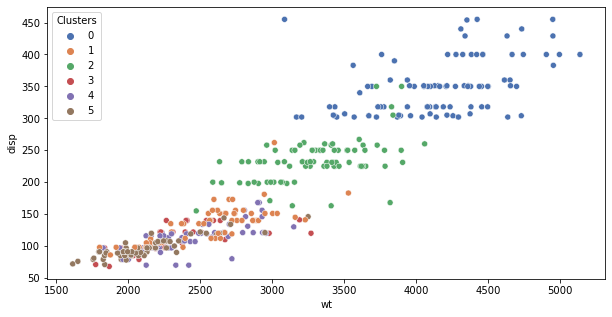

```python
plt.figure(figsize=(10,5))
sns.scatterplot(x= 'wt', y='disp', data = car_df, hue ='Clusters',palette="deep",
    sizes=(20, 200), legend = 'full' )
```

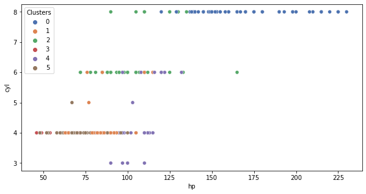

```python
plt.figure(figsize=(10,5))
sns.scatterplot(x= 'hp', y='cyl', data =  car_df, hue ='Clusters',palette="deep" )
```

### Cluster group 0 has an avg : 8 cylinders, displacement 350cc and 162 HP

### Cluster group 1 has an avg : 4 cylinders, displacement 134cc and 84 HP

### Cluster group 2 has an avg : 6 cylinders, displacement 234cc and 101 HP

### Cluster group 3 has an avg : 4 cylinders, displacement 111cc and 75 HP

### Cluster group 4 has an avg : 4 cylinders, displacement 111cc and 93 HP

### Cluster group 5 has an avg : 4 cylinders, displacement 96cc and 68 HP

### Adding a Datapoint to be selected into a cluster group, car name : Extra car

```python
df2 = {'mpg': 18 , 'cyl': 8, 'disp': 500 , 'hp':135, 'wt':3600, 'acc':13 , 'yr':69, 'origin': 1, 'car_name': 'Extra Car'}
copy_df = copy_df.append(df2, ignore_index = True)
copy_df.tail()
```

|  | mpg | cyl | disp | hp | wt | acc | yr | origin | car_name |
| --- | --- | --- | --- | --- | --- | --- | --- | --- | --- |
| 394 | 44.0 | 4 | 97.0 | 52.0 | 2130 | 24.6 | 82 | 2 | vw pickup |
| 395 | 32.0 | 4 | 135.0 | 84.0 | 2295 | 11.6 | 82 | 1 | dodge rampage |
| 396 | 28.0 | 4 | 120.0 | 79.0 | 2625 | 18.6 | 82 | 1 | ford ranger |
| 397 | 31.0 | 4 | 119.0 | 82.0 | 2720 | 19.4 | 82 | 1 | chevy s-10 |
| 398 | 18.0 | 8 | 500.0 | 135.0 | 3600 | 13.0 | 69 | 1 | Extra Car |

```python
c_df_n = copy_df.drop(['car_name'],axis=1)
c_df_n.dtypes
```

```
mpg       float64
cyl         int64
disp      float64
hp        float64
wt          int64
acc       float64
yr          int64
origin      int64
dtype: object
```

```python
c_df_nscaled = c_df_n.apply(zscore)
c_df_nscaled
```

|  | mpg | cyl | disp | hp | wt | acc | yr | origin |
| --- | --- | --- | --- | --- | --- | --- | --- | --- |
| 0 | -0.705112 | 1.492122 | 1.072995 | 0.671401 | 0.629357 | -1.293377 | -1.617419 | -0.713791 |
| 1 | -1.089666 | 1.492122 | 1.482006 | 1.588650 | 0.852946 | -1.474946 | -1.617419 | -0.713791 |
| 2 | -0.705112 | 1.492122 | 1.177626 | 1.195543 | 0.548913 | -1.656516 | -1.617419 | -0.713791 |
| 3 | -0.961481 | 1.492122 | 1.044459 | 1.195543 | 0.545364 | -1.293377 | -1.617419 | -0.713791 |
| 4 | -0.833297 | 1.492122 | 1.025436 | 0.933472 | 0.564292 | -1.838086 | -1.617419 | -0.713791 |
| ... | ... | ... | ... | ... | ... | ... | ... | ... |
| 394 | 2.627689 | -0.858743 | -0.924500 | -1.372753 | -0.996095 | 3.282179 | 1.621478 | 0.535343 |
| 395 | 1.089473 | -0.858743 | -0.563049 | -0.534126 | -0.800899 | -1.438632 | 1.621478 | -0.713791 |
| 396 | 0.576735 | -0.858743 | -0.705727 | -0.665161 | -0.410507 | 1.103343 | 1.621478 | -0.713791 |
| 397 | 0.961289 | -0.858743 | -0.715239 | -0.586540 | -0.298121 | 1.393854 | 1.621478 | -0.713791 |
| 398 | -0.705112 | 1.492122 | 2.908788 | 0.802437 | 0.742926 | -0.930237 | -1.887328 | -0.713791 |

399 rows × 8 columns

```python
k_means = KMeans(n_clusters = 6)    # K = 6 clusters
k_means.fit(c_df_nscaled)
labels = k_means.labels_
```

```python
copy_df['Clusters']=labels
copy_df.tail()
```

|  | mpg | cyl | disp | hp | wt | acc | yr | origin | car_name | Clusters |
| --- | --- | --- | --- | --- | --- | --- | --- | --- | --- | --- |
| 394 | 44.0 | 4 | 97.0 | 52.0 | 2130 | 24.6 | 82 | 2 | vw pickup | 0 |
| 395 | 32.0 | 4 | 135.0 | 84.0 | 2295 | 11.6 | 82 | 1 | dodge rampage | 4 |
| 396 | 28.0 | 4 | 120.0 | 79.0 | 2625 | 18.6 | 82 | 1 | ford ranger | 4 |
| 397 | 31.0 | 4 | 119.0 | 82.0 | 2720 | 19.4 | 82 | 1 | chevy s-10 | 4 |
| 398 | 18.0 | 8 | 500.0 | 135.0 | 3600 | 13.0 | 69 | 1 | Extra Car | 1 |

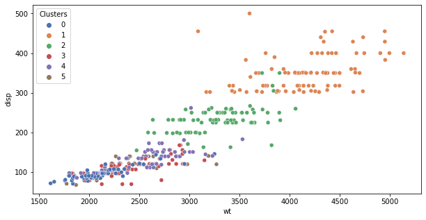

```python
plt.figure(figsize=(10,5))
sns.scatterplot(x= 'wt', y='disp', data = copy_df, hue ='Clusters',palette="deep",
    sizes=(20, 200), legend = 'full' )
```

### As we can see from above the New Datapoint 'Extra Car', having weight = 3600units and displacement of 500 is grouped into Cluster group 1

### PART B

```python
df = pd.read_csv('vehicle.csv')
```

```python
df.info()
```

```
<class 'pandas.core.frame.DataFrame'>
RangeIndex: 846 entries, 0 to 845
Data columns (total 19 columns):
 #   Column                       Non-Null Count  Dtype
---  ------                       --------------  -----
 0   compactness                  846 non-null    int64
 1   circularity                  841 non-null    float64
 2   distance_circularity         842 non-null    float64
 3   radius_ratio                 840 non-null    float64
 4   pr.axis_aspect_ratio         844 non-null    float64
 5   max.length_aspect_ratio      846 non-null    int64
 6   scatter_ratio                845 non-null    float64
 7   elongatedness                845 non-null    float64
 8   pr.axis_rectangularity       843 non-null    float64
 9   max.length_rectangularity    846 non-null    int64
 10  scaled_variance              843 non-null    float64
 11  scaled_variance.1            844 non-null    float64
 12  scaled_radius_of_gyration    844 non-null    float64
 13  scaled_radius_of_gyration.1  842 non-null    float64
 14  skewness_about               840 non-null    float64
 15  skewness_about.1             845 non-null    float64
 16  skewness_about.2             845 non-null    float64
 17  hollows_ratio                846 non-null    int64
 18  class                        846 non-null    object
dtypes: float64(14), int64(4), object(1)
memory usage: 125.7+ KB
```

```python
df.head()
```

|  | compactness | circularity | distance_circularity | radius_ratio | pr.axis_aspect_ratio | max.length_aspect_ratio | scatter_ratio | elongatedness | pr.axis_rectangularity | max.length_rectangularity | scaled_variance | scaled_variance.1 | scaled_radius_of_gyration | scaled_radius_of_gyration.1 | skewness_about | skewness_about.1 | skewness_about.2 | hollows_ratio | class |
| --- | --- | --- | --- | --- | --- | --- | --- | --- | --- | --- | --- | --- | --- | --- | --- | --- | --- | --- | --- |
| 0 | 95 | 48.0 | 83.0 | 178.0 | 72.0 | 10 | 162.0 | 42.0 | 20.0 | 159 | 176.0 | 379.0 | 184.0 | 70.0 | 6.0 | 16.0 | 187.0 | 197 | van |
| 1 | 91 | 41.0 | 84.0 | 141.0 | 57.0 | 9 | 149.0 | 45.0 | 19.0 | 143 | 170.0 | 330.0 | 158.0 | 72.0 | 9.0 | 14.0 | 189.0 | 199 | van |
| 2 | 104 | 50.0 | 106.0 | 209.0 | 66.0 | 10 | 207.0 | 32.0 | 23.0 | 158 | 223.0 | 635.0 | 220.0 | 73.0 | 14.0 | 9.0 | 188.0 | 196 | car |
| 3 | 93 | 41.0 | 82.0 | 159.0 | 63.0 | 9 | 144.0 | 46.0 | 19.0 | 143 | 160.0 | 309.0 | 127.0 | 63.0 | 6.0 | 10.0 | 199.0 | 207 | van |
| 4 | 85 | 44.0 | 70.0 | 205.0 | 103.0 | 52 | 149.0 | 45.0 | 19.0 | 144 | 241.0 | 325.0 | 188.0 | 127.0 | 9.0 | 11.0 | 180.0 | 183 | bus |

```python
df.isnull().sum()
```

```
compactness                    0
circularity                    5
distance_circularity           4
radius_ratio                   6
pr.axis_aspect_ratio           2
max.length_aspect_ratio        0
scatter_ratio                  1
elongatedness                  1
pr.axis_rectangularity         3
max.length_rectangularity      0
scaled_variance                3
scaled_variance.1              2
scaled_radius_of_gyration      2
scaled_radius_of_gyration.1    4
skewness_about                 6
skewness_about.1               1
skewness_about.2               1
hollows_ratio                  0
class                          0
dtype: int64
```

### We can see that there are some null values in the dataframe, we will impute these with the median of the corresponding columns

```python
df = df.fillna(df.median())
df.isnull().sum()
```

```
compactness                    0
circularity                    0
distance_circularity           0
radius_ratio                   0
pr.axis_aspect_ratio           0
max.length_aspect_ratio        0
scatter_ratio                  0
elongatedness                  0
pr.axis_rectangularity         0
max.length_rectangularity      0
scaled_variance                0
scaled_variance.1              0
scaled_radius_of_gyration      0
scaled_radius_of_gyration.1    0
skewness_about                 0
skewness_about.1               0
skewness_about.2               0
hollows_ratio                  0
class                          0
dtype: int64
```

### The piechart for Class variable in the Dataframe

[output not shown]

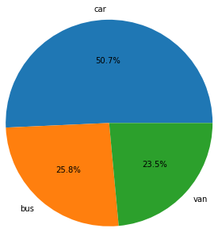

```python
dfclass=pd.DataFrame(df['class'].value_counts())
plt.pie(df['class'].value_counts(),labels=dfclass.index,
autopct='%1.1f%%', radius = 1.5)
```

```python
df.duplicated().sum()
```

```
0
```

### There are 0 duplicate values in the dataframe

```python
df.info()
```

```
<class 'pandas.core.frame.DataFrame'>
RangeIndex: 846 entries, 0 to 845
Data columns (total 19 columns):
 #   Column                       Non-Null Count  Dtype
---  ------                       --------------  -----
 0   compactness                  846 non-null    int64
 1   circularity                  846 non-null    float64
 2   distance_circularity         846 non-null    float64
 3   radius_ratio                 846 non-null    float64
 4   pr.axis_aspect_ratio         846 non-null    float64
 5   max.length_aspect_ratio      846 non-null    int64
 6   scatter_ratio                846 non-null    float64
 7   elongatedness                846 non-null    float64
 8   pr.axis_rectangularity       846 non-null    float64
 9   max.length_rectangularity    846 non-null    int64
 10  scaled_variance              846 non-null    float64
 11  scaled_variance.1            846 non-null    float64
 12  scaled_radius_of_gyration    846 non-null    float64
 13  scaled_radius_of_gyration.1  846 non-null    float64
 14  skewness_about               846 non-null    float64
 15  skewness_about.1             846 non-null    float64
 16  skewness_about.2             846 non-null    float64
 17  hollows_ratio                846 non-null    int64
 18  class                        846 non-null    object
dtypes: float64(14), int64(4), object(1)
memory usage: 125.7+ KB
```

```python
x = df.iloc[:,0:18]  # splitting the data into X data and Y data
y = df['class']
```

```python
xscaled = x.apply(zscore)
```

```python
len(x.columns)
```

```
18
```

```python
from sklearn.model_selection import train_test_split

x_train,x_test,y_train,y_test = train_test_split(x, y, test_size=0.2, random_state = 10)
```

```python
x_train_sd = x_train.apply(zscore)
x_test_sd = x_test.apply(zscore)

from sklearn.svm import SVC
clf = SVC()
clf.fit(x_train_sd,y_train)
clf.score(x_test_sd,y_test)
```

```
0.9588235294117647
```

```python
from sklearn.model_selection import GridSearchCV
from sklearn import metrics

y_pred = clf.predict(x_test_sd)
print(metrics.classification_report(y_test,y_pred))
```

```
              precision    recall  f1-score   support

         bus       1.00      0.98      0.99        44
         car       0.97      0.97      0.97        89
         van       0.89      0.92      0.91        37

    accuracy                           0.96       170
   macro avg       0.95      0.95      0.95       170
weighted avg       0.96      0.96      0.96       170
```

### 96% accuracy is seen in the predictions

### Applying PCA

```python
cov_matrix = np.cov(x_train_sd.T)
pd.DataFrame(cov_matrix)
```

|  | 0 | 1 | 2 | 3 | 4 | 5 | 6 | 7 | 8 | 9 | 10 | 11 | 12 | 13 | 14 | 15 | 16 | 17 |
| --- | --- | --- | --- | --- | --- | --- | --- | --- | --- | --- | --- | --- | --- | --- | --- | --- | --- | --- |
| 0 | 1.001481 | 0.691004 | 0.793103 | 0.675576 | 0.077559 | 0.131934 | 0.810632 | -0.784760 | 0.813298 | 0.689931 | 0.751945 | 0.811099 | 0.591271 | -0.257066 | 0.244540 | 0.165968 | 0.305733 | 0.376995 |
| 1 | 0.691004 | 1.001481 | 0.789577 | 0.628992 | 0.165045 | 0.230535 | 0.846603 | -0.821088 | 0.841062 | 0.962971 | 0.794145 | 0.834915 | 0.924947 | 0.041352 | 0.146233 | 0.004786 | -0.081968 | 0.067218 |
| 2 | 0.793103 | 0.789577 | 1.001481 | 0.759475 | 0.148281 | 0.240603 | 0.905319 | -0.911021 | 0.894321 | 0.778256 | 0.856901 | 0.886599 | 0.705052 | -0.225512 | 0.117538 | 0.279808 | 0.155906 | 0.344276 |
| 3 | 0.675576 | 0.628992 | 0.759475 | 1.001481 | 0.670081 | 0.473544 | 0.728175 | -0.781766 | 0.702848 | 0.586698 | 0.795677 | 0.711237 | 0.543158 | -0.141502 | 0.042430 | 0.180012 | 0.373912 | 0.472377 |
| 4 | 0.077559 | 0.165045 | 0.148281 | 0.670081 | 1.001481 | 0.693324 | 0.097027 | -0.173749 | 0.073179 | 0.144688 | 0.288059 | 0.082110 | 0.132446 | 0.215539 | -0.072877 | -0.037796 | 0.217148 | 0.253323 |
| 5 | 0.131934 | 0.230535 | 0.240603 | 0.473544 | 0.693324 | 1.001481 | 0.147412 | -0.161795 | 0.141738 | 0.282427 | 0.331352 | 0.126389 | 0.176414 | 0.352906 | 0.001275 | 0.042772 | -0.028801 | 0.128605 |
| 6 | 0.810632 | 0.846603 | 0.905319 | 0.728175 | 0.097027 | 0.147412 | 1.001481 | -0.972715 | 0.990596 | 0.813604 | 0.941741 | 0.993669 | 0.800544 | -0.039548 | 0.082213 | 0.223937 | 0.011936 | 0.131840 |
| 7 | -0.784760 | -0.821088 | -0.911021 | -0.781766 | -0.173749 | -0.161795 | -0.972715 | 1.001481 | -0.949803 | -0.779909 | -0.929611 | -0.954567 | -0.768020 | 0.109420 | -0.058652 | -0.198494 | -0.117865 | -0.227427 |
| 8 | 0.813298 | 0.841062 | 0.894321 | 0.702848 | 0.073179 | 0.141738 | 0.990596 | -0.949803 | 1.001481 | 0.814872 | 0.927509 | 0.988967 | 0.796512 | -0.029962 | 0.092009 | 0.226847 | -0.008192 | 0.114989 |
| 9 | 0.689931 | 0.962971 | 0.778256 | 0.586698 | 0.144688 | 0.282427 | 0.813604 | -0.779909 | 0.814872 | 1.001481 | 0.750872 | 0.800699 | 0.870233 | 0.032716 | 0.135934 | 0.015877 | -0.078962 | 0.096002 |
| 10 | 0.751945 | 0.794145 | 0.856901 | 0.795677 | 0.288059 | 0.331352 | 0.941741 | -0.929611 | 0.927509 | 0.750872 | 1.001481 | 0.938062 | 0.780150 | 0.129014 | 0.044292 | 0.205400 | 0.012207 | 0.092150 |
| 11 | 0.811099 | 0.834915 | 0.886599 | 0.711237 | 0.082110 | 0.126389 | 0.993669 | -0.954567 | 0.988967 | 0.800699 | 0.938062 | 1.001481 | 0.796028 | -0.028955 | 0.085303 | 0.210943 | 0.013274 | 0.117272 |
| 12 | 0.591271 | 0.924947 | 0.705052 | 0.543158 | 0.132446 | 0.176414 | 0.800544 | -0.768020 | 0.796512 | 0.870233 | 0.780150 | 0.796028 | 1.001481 | 0.180638 | 0.169210 | -0.044812 | -0.207694 | -0.099775 |
| 13 | -0.257066 | 0.041352 | -0.225512 | -0.141502 | 0.215539 | 0.352906 | -0.039548 | 0.109420 | -0.029962 | 0.032716 | 0.129014 | -0.028955 | 0.180638 | 1.001481 | -0.081816 | -0.121538 | -0.739354 | -0.782706 |
| 14 | 0.244540 | 0.146233 | 0.117538 | 0.042430 | -0.072877 | 0.001275 | 0.082213 | -0.058652 | 0.092009 | 0.135934 | 0.044292 | 0.085303 | 0.169210 | -0.081816 | 1.001481 | -0.026249 | 0.101633 | 0.083512 |
| 15 | 0.165968 | 0.004786 | 0.279808 | 0.180012 | -0.037796 | 0.042772 | 0.223937 | -0.198494 | 0.226847 | 0.015877 | 0.205400 | 0.210943 | -0.044812 | -0.121538 | -0.026249 | 1.001481 | 0.062416 | 0.194700 |
| 16 | 0.305733 | -0.081968 | 0.155906 | 0.373912 | 0.217148 | -0.028801 | 0.011936 | -0.117865 | -0.008192 | -0.078962 | 0.012207 | 0.013274 | -0.207694 | -0.739354 | 0.101633 | 0.062416 | 1.001481 | 0.895565 |
| 17 | 0.376995 | 0.067218 | 0.344276 | 0.472377 | 0.253323 | 0.128605 | 0.131840 | -0.227427 | 0.114989 | 0.096002 | 0.092150 | 0.117272 | -0.099775 | -0.782706 | 0.083512 | 0.194700 | 0.895565 | 1.001481 |

```python
eigen_values,eigen_vectors = np.linalg.eig(cov_matrix)
print('E values', eigen_values)
print('E vectors', eigen_vectors)
tot = sum(eigen_values)
```

```
E values [9.39946930e+00 2.94735116e+00 2.02509122e+00 1.16976888e+00
 9.29162275e-01 4.98304443e-01 3.47840418e-01 2.23503437e-01
 1.55732096e-01 9.13755126e-02 6.93766156e-02 4.91931337e-02
 3.76590483e-02 3.57104465e-03 1.08906517e-02 2.84321725e-02
 1.81058409e-02 2.18394217e-02]
E vectors [[ 0.27518888 -0.13288603  0.10949427 -0.08289679 -0.08326625  0.15103023
   0.44765909  0.59348271  0.45023193  0.26336076 -0.01122904  0.02913889
  -0.16077874 -0.0128978  -0.00750691  0.04731452 -0.06301594 -0.00791814]
 [ 0.29333533  0.11906336  0.03468822 -0.18875633  0.0918208  -0.34438446
  -0.21417133  0.16256565  0.00938602 -0.11902405 -0.01839014 -0.21314836
  -0.08108791 -0.01144966  0.06411562 -0.44903196 -0.18477111 -0.59749891]
 [ 0.30430178 -0.07549181  0.05330307  0.08024136 -0.03925393 -0.12005407
   0.11120016 -0.42770384  0.16546272  0.28525487 -0.6818474  -0.01024759
   0.22320444  0.01063023 -0.03375544  0.14925517  0.05863802 -0.17496945]
 [ 0.26729181 -0.16729373 -0.29509011  0.03662491  0.03316715  0.22686089
  -0.21362957 -0.07935982  0.25701982  0.0373638   0.09676981 -0.16501534
   0.05921674 -0.04776436 -0.05381037 -0.45117361  0.59501788  0.193157  ]
 [ 0.08040991 -0.07638788 -0.63801694 -0.04726638  0.03181888  0.17260248
  -0.40943244  0.07723298  0.2955582  -0.08612145 -0.04892563  0.12088367
   0.03804677  0.03588867  0.02683923  0.33725656 -0.37092659 -0.08621453]
 [ 0.09239565  0.04469484 -0.58645628 -0.02226227 -0.19686284 -0.35005262
   0.5391532  -0.19034966 -0.15897562  0.08275307  0.29506257 -0.13961468
  -0.04466306 -0.01041763 -0.02737305  0.06820413  0.05263693 -0.08875423]
 [ 0.31667422  0.04527076  0.10106497  0.09560541  0.01834711  0.13624415
   0.04860415 -0.1011492  -0.04096958 -0.17962634  0.15921989  0.0940704
  -0.04111736  0.84801262 -0.22067162  0.06245586  0.01730987 -0.07045677]
 [-0.31365923  0.01302569 -0.05852091 -0.08300773 -0.07398406 -0.16465509
   0.04232029  0.22207654  0.12791809  0.13635357  0.05273304  0.09581877
   0.80704645  0.2427673  -0.04622654 -0.21559523 -0.04017917 -0.00542719]
 [ 0.31360126  0.05481848  0.11368636  0.09285498  0.00152691  0.1185093
   0.08657283 -0.05981329 -0.00326302 -0.21290564  0.23849047  0.23851114
   0.29497872 -0.11795534  0.72043673  0.1658979   0.14728228 -0.15397852]
 [ 0.28483017  0.10909824  0.02533827 -0.18603686  0.07411305 -0.48412001
  -0.04043628  0.21292486  0.05441318 -0.44802905 -0.18137493 -0.11808561
   0.10174707 -0.01575519 -0.04335902  0.20639062  0.0948684   0.51987584]
 [ 0.30815554  0.07317697 -0.06549639  0.11519102 -0.00679236  0.25845661
   0.08171496 -0.03244388 -0.30696177  0.13926442 -0.07742889 -0.23692054
   0.13522629  0.0020132   0.16771391 -0.33699656 -0.54795845  0.41419884]
 [ 0.31338142  0.05016158  0.11183697  0.0894255   0.0220013   0.17669913
   0.0627764  -0.04292414 -0.08013477 -0.18913136  0.22573808  0.1705719
   0.30663707 -0.44859419 -0.62370263  0.06951295 -0.09460975 -0.14486441]
 [ 0.27248158  0.20639959  0.04734891 -0.20489438  0.06905    -0.18148941
  -0.35448092  0.09689681 -0.2562209   0.66448763  0.22853928  0.19307517
  -0.00711552  0.01244441 -0.02516136  0.20347535  0.12791696  0.10427182]
 [-0.02145534  0.49996155 -0.27208542  0.05426149 -0.13881825  0.22351939
   0.08044584  0.33632634 -0.32708009 -0.10702184 -0.42989019  0.29596141
  -0.05213599  0.00495332 -0.0261759  -0.11157879  0.25913424 -0.09961389]
 [ 0.04289142 -0.05076613  0.11826307 -0.57805414 -0.75778324  0.16728095
  -0.10360668 -0.15311409 -0.01503407 -0.09660504  0.00133872 -0.00226682
  -0.00667298 -0.00225169  0.00266656 -0.01542875 -0.02534802  0.02347344]
 [ 0.062666   -0.11770259  0.0582145   0.68722236 -0.5681486  -0.24592945
  -0.26242062  0.2096381  -0.02323848  0.02745051  0.03799816 -0.07169833
  -0.02635763 -0.01152629 -0.00888115  0.03985733  0.00102781 -0.00972363]
 [ 0.03384691 -0.54589384 -0.04805075 -0.11453254  0.09120095  0.15679821
  -0.01508527  0.29758044 -0.5138115  -0.02867835 -0.12150555 -0.35292193
   0.1638908   0.04579309  0.00189405  0.25521746  0.17211579 -0.1894201 ]
 [ 0.07907603 -0.54282143 -0.07702387 -0.04467869  0.03174139 -0.22873542
   0.03938951 -0.01071278 -0.17910664 -0.05877937 -0.08772425  0.68089595
  -0.13321244 -0.00578065  0.00674544 -0.30362557 -0.09192655  0.10419608]]
```

```python
var_explained = [(i/tot)*100 for i in sorted(eigen_values,reverse=True)]
var_explained
```

```
[52.14202644696554,
 16.349950936562855,
 11.233864041292927,
 6.489102487661541,
 5.15437652808752,
 2.764262812743107,
 1.9295881172823202,
 1.23984894521728,
 0.8638984611736091,
 0.5068907875140051,
 0.3848554861030907,
 0.2728909046071507,
 0.20890744254592886,
 0.15772285059950508,
 0.12115063837134087,
 0.10043920612929631,
 0.060414118035145487,
 0.01980978910780081]
```

```python
var_explained[0:10]  # these are the first 10 principal component values of the data
```

```
[52.14202644696554,
 16.349950936562855,
 11.233864041292927,
 6.489102487661541,
 5.15437652808752,
 2.764262812743107,
 1.9295881172823202,
 1.23984894521728,
 0.8638984611736091,
 0.5068907875140051]
```

```python
var_explained[0:5]  # these are the first 5 principal component values of the data
```

```
[52.14202644696554,
 16.349950936562855,
 11.233864041292927,
 6.489102487661541,
 5.15437652808752]
```

```python
cum_var = np.cumsum(var_explained)
cum_var
```

```
array([ 52.14202645,  68.49197738,  79.72584142,  86.21494391,
        91.36932044,  94.13358325,  96.06317137,  97.30302032,
        98.16691878,  98.67380956,  99.05866505,  99.33155596,
        99.5404634 ,  99.69818625,  99.81933689,  99.91977609,
        99.98019021, 100.        ])
```

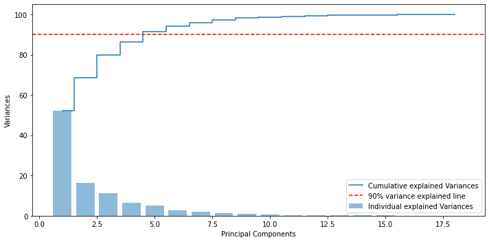

```python
plt.figure(figsize=(10,5))
plt.bar(range(1,eigen_values.size+1), var_explained, alpha=0.5, align='center', label='Individual explained Variances')
plt.step(range(1,eigen_values.size+1), cum_var, where='mid', label='Cumulative explained Variances')
plt.axhline(y = 90, color = 'r', linestyle = '--',label='90% variance explained line')
plt.ylabel('Variances')
plt.xlabel('Principal Components')
plt.legend(loc='best')
plt.tight_layout()
plt.show()
```

```python
eigen_pairs = [(np.abs(eigen_values[i]), eigen_vectors[:,i]) for i in range(len(eigen_values))]
eigen_pairs.sort(reverse=True)
eigen_pairs[:]
```

```
[(9.399469300839657,
  array([ 0.27518888,  0.29333533,  0.30430178,  0.26729181,  0.08040991,
          0.09239565,  0.31667422, -0.31365923,  0.31360126,  0.28483017,
          0.30815554,  0.31338142,  0.27248158, -0.02145534,  0.04289142,
          0.062666  ,  0.03384691,  0.07907603])),
 (2.947351155497732,
  array([-0.13288603,  0.11906336, -0.07549181, -0.16729373, -0.07638788,
          0.04469484,  0.04527076,  0.01302569,  0.05481848,  0.10909824,
          0.07317697,  0.05016158,  0.20639959,  0.49996155, -0.05076613,
         -0.11770259, -0.54589384, -0.54282143])),
 (2.0250912245104056,
  array([ 0.10949427,  0.03468822,  0.05330307, -0.29509011, -0.63801694,
         -0.58645628,  0.10106497, -0.05852091,  0.11368636,  0.02533827,
         -0.06549639,  0.11183697,  0.04734891, -0.27208542,  0.11826307,
          0.0582145 , -0.04805075, -0.07702387])),
 (1.1697688751091209,
  array([-0.08289679, -0.18875633,  0.08024136,  0.03662491, -0.04726638,
         -0.02226227,  0.09560541, -0.08300773,  0.09285498, -0.18603686,
          0.11519102,  0.0894255 , -0.20489438,  0.05426149, -0.57805414,
          0.68722236, -0.11453254, -0.04467869])),
 (0.9291622754632437,
  array([-0.08326625,  0.0918208 , -0.03925393,  0.03316715,  0.03181888,
         -0.19686284,  0.01834711, -0.07398406,  0.00152691,  0.07411305,
         -0.00679236,  0.0220013 ,  0.06905   , -0.13881825, -0.75778324,
         -0.5681486 ,  0.09120095,  0.03174139])),
 (0.49830444304382426,
  array([ 0.15103023, -0.34438446, -0.12005407,  0.22686089,  0.17260248,
         -0.35005262,  0.13624415, -0.16465509,  0.1185093 , -0.48412001,
          0.25845661,  0.17669913, -0.18148941,  0.22351939,  0.16728095,
         -0.24592945,  0.15679821, -0.22873542])),
 (0.34784041794209297,
  array([ 0.44765909, -0.21417133,  0.11120016, -0.21362957, -0.40943244,
          0.5391532 ,  0.04860415,  0.04232029,  0.08657283, -0.04043628,
          0.08171496,  0.0627764 , -0.35448092,  0.08044584, -0.10360668,
         -0.26242062, -0.01508527,  0.03938951])),
 (0.22350343652450175,
  array([ 0.59348271,  0.16256565, -0.42770384, -0.07935982,  0.07723298,
         -0.19034966, -0.1011492 ,  0.22207654, -0.05981329,  0.21292486,
         -0.03244388, -0.04292414,  0.09689681,  0.33632634, -0.15311409,
          0.2096381 ,  0.29758044, -0.01071278])),
```

[output cut: 35 more lines]

```
 (0.018105840891574486,
  array([-0.06301594, -0.18477111,  0.05863802,  0.59501788, -0.37092659,
          0.05263693,  0.01730987, -0.04017917,  0.14728228,  0.0948684 ,
         -0.54795845, -0.09460975,  0.12791696,  0.25913424, -0.02534802,
          0.00102781,  0.17211579, -0.09192655])),
 (0.010890651677802229,
  array([-0.00750691,  0.06411562, -0.03375544, -0.05381037,  0.02683923,
         -0.02737305, -0.22067162, -0.04622654,  0.72043673, -0.04335902,
          0.16771391, -0.62370263, -0.02516136, -0.0261759 ,  0.00266656,
         -0.00888115,  0.00189405,  0.00674544])),
 (0.003571044649832894,
  array([-0.0128978 , -0.01144966,  0.01063023, -0.04776436,  0.03588867,
         -0.01041763,  0.84801262,  0.2427673 , -0.11795534, -0.01575519,
          0.0020132 , -0.44859419,  0.01244441,  0.00495332, -0.00225169,
         -0.01152629,  0.04579309, -0.00578065]))]
```

```python
len(eigen_vectors[0])
```

```
18
```

```python
# PCA 5 component matrix for dimension reduction of the data

w = np.hstack((eigen_pairs[i][1].reshape(18,1))
              for i in range(0,5)
             )
w
```

```
array([[ 0.27518888, -0.13288603,  0.10949427, -0.08289679, -0.08326625],
       [ 0.29333533,  0.11906336,  0.03468822, -0.18875633,  0.0918208 ],
       [ 0.30430178, -0.07549181,  0.05330307,  0.08024136, -0.03925393],
       [ 0.26729181, -0.16729373, -0.29509011,  0.03662491,  0.03316715],
       [ 0.08040991, -0.07638788, -0.63801694, -0.04726638,  0.03181888],
       [ 0.09239565,  0.04469484, -0.58645628, -0.02226227, -0.19686284],
       [ 0.31667422,  0.04527076,  0.10106497,  0.09560541,  0.01834711],
       [-0.31365923,  0.01302569, -0.05852091, -0.08300773, -0.07398406],
       [ 0.31360126,  0.05481848,  0.11368636,  0.09285498,  0.00152691],
       [ 0.28483017,  0.10909824,  0.02533827, -0.18603686,  0.07411305],
       [ 0.30815554,  0.07317697, -0.06549639,  0.11519102, -0.00679236],
       [ 0.31338142,  0.05016158,  0.11183697,  0.0894255 ,  0.0220013 ],
       [ 0.27248158,  0.20639959,  0.04734891, -0.20489438,  0.06905   ],
       [-0.02145534,  0.49996155, -0.27208542,  0.05426149, -0.13881825],
       [ 0.04289142, -0.05076613,  0.11826307, -0.57805414, -0.75778324],
       [ 0.062666  , -0.11770259,  0.0582145 ,  0.68722236, -0.5681486 ],
       [ 0.03384691, -0.54589384, -0.04805075, -0.11453254,  0.09120095],
       [ 0.07907603, -0.54282143, -0.07702387, -0.04467869,  0.03174139]])
```

### This is the Matrix with which we can dimensionally reduce the data using 5 Principal Components we derived

```python
x_train_pca = x_train_sd.dot(w)
x_test_pca = x_test_sd.dot(w)

clf.fit(x_train_sd,y_train)
print('Score before PCA:', clf.score(x_test_sd,y_test))

clf.fit(x_train_pca,y_train)
print('Score after PCA:', clf.score(x_test_pca,y_test))
```

```
Score before PCA: 0.9588235294117647
Score after PCA: 0.7705882352941177
```

```python
from sklearn.metrics import classification_report
y_pred = clf.predict(x_test_pca)
print(classification_report(y_test,y_pred))
```

```
              precision    recall  f1-score   support

         bus       0.78      0.70      0.74        44
         car       0.84      0.85      0.84        89
         van       0.62      0.65      0.63        37

    accuracy                           0.77       170
   macro avg       0.74      0.74      0.74       170
weighted avg       0.77      0.77      0.77       170
```

### 77% accuracy is seen in the predictions

### Parameter Tuning the SVC

```python
param_grid = {'C':[0.1,1,10,100,1000],
             'gamma':[1,0.1,0.01,0.001,0.0001],
             'kernel':['rbf','linear']}

grid = GridSearchCV(SVC(),param_grid,refit = True,verbose=3)
```

```python
grid.fit(x_train_pca, y_train)
```

[output not shown]

[output cut: 196 more lines]

[output not shown]

```
GridSearchCV(estimator=SVC(),
             param_grid={'C': [0.1, 1, 10, 100, 1000],
                         'gamma': [1, 0.1, 0.01, 0.001, 0.0001],
                         'kernel': ['rbf', 'linear']},
             verbose=3)
```

```python
print(grid.best_estimator_)  # Best parameters after tuning
print(grid.best_params_)
```

```
SVC(C=1000, gamma=0.01)
{'C': 1000, 'gamma': 0.01, 'kernel': 'rbf'}
```

```python
from sklearn.metrics import classification_report
y_pred = grid.predict(x_test_pca)
print(classification_report(y_test,y_pred))
```

```
              precision    recall  f1-score   support

         bus       0.71      0.77      0.74        44
         car       0.89      0.81      0.85        89
         van       0.73      0.81      0.77        37

    accuracy                           0.80       170
   macro avg       0.78      0.80      0.79       170
weighted avg       0.81      0.80      0.80       170
```

```python
print('Score after PCA with parameter tuning:', grid.score(x_test_pca,y_test))
```

```
Score after PCA with parameter tuning: 0.8
```

### Here we see that using just the:

### SVC classifier we are getting : 95.88 % ~ 96.00% accuracy

### SVC classifier after PCA of 90% minimum variance explained(5 components) = 77.05 % accuracy

### SVC classifier (parameter tuned) after PCA of 90% minimum variance explained(5 components) = 80.00 % accuracy

### Here the accuracy has dropped from 96% to 77% after performing PCA of 5 components which covers 90% variance and after parameter tuning the accuracy increased to 80%

### Assumptions of PCA

1. PCA assumes a linear relationship between attributes
2. There is no guarantee that the directions of maximum variance components will contain good features for analysis.
3. It assumes feature set to be correlated and that the reduced feature set after applying PCA will represent the original data set in an effective way with fewer dimensions
4. PCA assumes that components with larger variance correspond to better infomrmation for analysis and thus should be paid more attention and components with lower variance correspond to noise and thus can be ignored as well

### Advantages of PCA

1. Removes Correlated attributes
2. Improves Algorithm Performance
3. Reduces overfitting
4. Improves Visualization
5. Decreases storage requirements
6. Decreases problems of dimensionality

### Limitations of PCA

1. PCA effectiveness depends upon the scales of the attributes.
2. Changing scales of the variables can change the PCA
3. Presence of skew in data with long thick tail can impact the effectiveness of the PCA
4. PCA assumes linear relationship between attributes. It is ineffective when relationships are non linear 5.Information loss to a certain degree.